# BANA 7025 - Data Wrangling Project

##### Hypothesis 2

**Groups or groups with children tend to cancel the bookings more as the count increases**

The following plots will try and prove that as the count for group member would increase the rate of cancellation would also increase.

```r
pct_count <- hotels %>% mutate( group_size_n = adults + children + babies)%>%
          group_by(group_size_n)%>%
          summarise(total_count = n(),count_for_cancelled = sum(is_canceled ==  1),cancelled_pct = (count_for_cancelled/total_count) * 100)
```

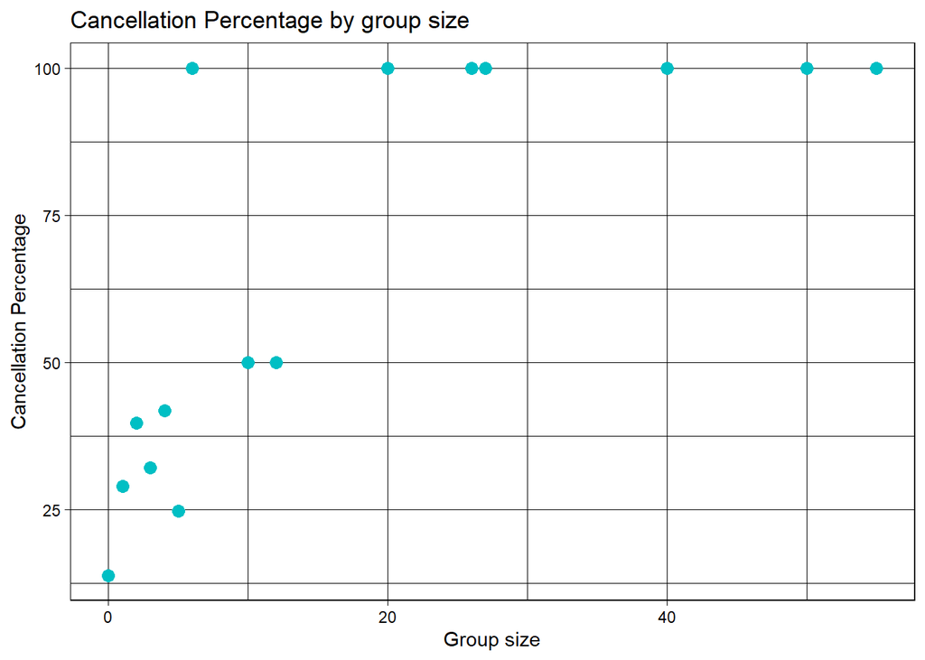

```r
 ggplot(pct_count,aes(group_size_n,cancelled_pct) )+
  geom_point(color = "#00BFC4",size = 3)+
  ggtitle("Cancellation Percentage by group size") +
            xlab("Group size") +
            ylab("Cancellation Percentage")+
  theme_linedraw()
```

**For groups with children**

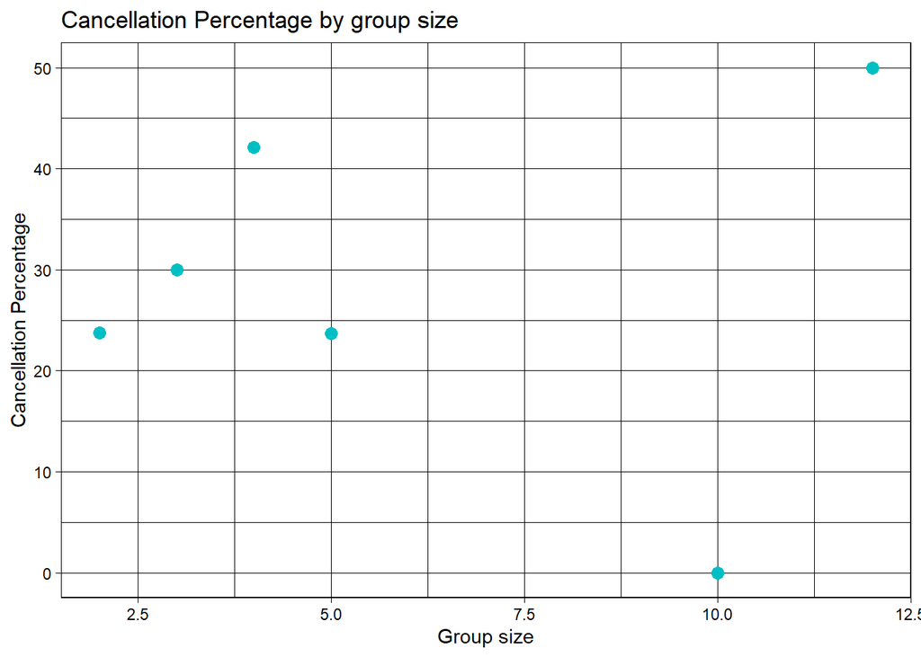

```r
hotels %>% filter(is_family ==TRUE)%>%
        mutate( group_size_n = adults + children + babies)%>%
                group_by(group_size_n)%>%
                summarise(total_count = n(),count_for_cancelled = sum(is_canceled ==             1),cancelled_pct = (count_for_cancelled/total_count) * 100) %>%
  ggplot(aes(group_size_n,cancelled_pct))+
  geom_point(color = "#00BFC4",size = 3)+
  ggtitle("Cancellation Percentage by group size") +
            xlab("Group size") +
            ylab("Cancellation Percentage")+
  theme_linedraw()
```

##### Hypothesis 3

**Booking would peak around July-August(mid - year) for visitors from different countries**

The hypothesis is that most of the people from different countries would visit around July and august i.e. is around the peak tourism season as summers are usually holiday season for kids.

```r
leadtime_by_month <-
  hotels %>%
    filter(is_canceled == 0) %>%
      mutate(arrival_date_month_short = str_sub(arrival_date_month,1,3),
             arrival_date_month_short = fct_relevel(arrival_date_month_short,
                                       "Jan",
                                        "Feb",
                                        "Mar",
                                        "Apr",
                                        "May",
                                        "Jun",
                                        "Jul",
                                        "Aug",
                                        "Sep",
                                        "Oct",
                                        "Nov",
                                        "Dec")) %>%
        group_by(new_country,arrival_date_month_short) %>%
          summarise(booking_count = n())
```

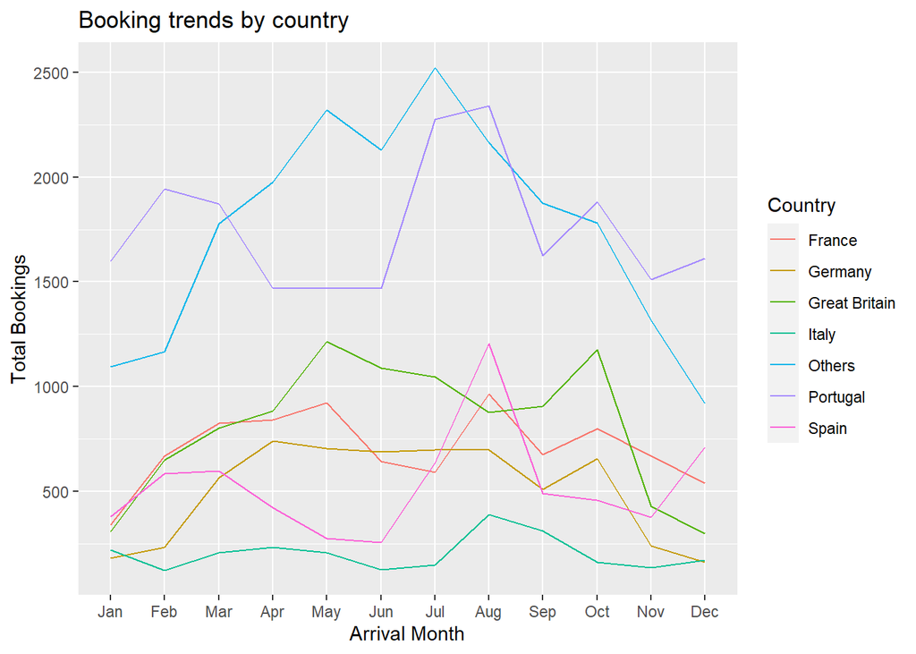

```r
ggplot(leadtime_by_month,aes(x=arrival_date_month_short,y=booking_count,group = new_country)) +
  geom_line(aes(color=as.character(new_country))) +
    xlab("Arrival Month") +
      ylab("Total Bookings") +
        ggtitle("Booking trends by country") +
          labs(color = "Country")
```

The peaks no. of visitors from most of the countries is around July and August. So our hypothesis stands validated as Summers and Early fall looks to be the most favorable season for visiting.

### 4.4 Booking Profile Features

#### 4.4.1 Hypothesis Proposed

The booking profile of the customer in consonance with the other feature types can be used to derive holistic insights from the data. Following hypothesis will be tested:

- There is a relation between the distribution channel and ability of the hotel to provide the requested room
- Hotels in the city have greater traffic and are more susceptible to overbooking
- There is a significant relation between the room types and the adr
- There is a significant relation between the market segment and the assigned room types
- There is a significant relation between the distribution channel and the reserved room types
- Certain room types can have a larger lead time
- Majority of the people tend to not pay deposits while booking
- Groups with children tend to pay deposits while booking
- People who do not pay deposit while booking tend to cancel the booking

We create a new variable that tracks the ability of the hotel to fulfil the booking by assigning the reserved room to its customer.

```r
hotels$same_room <- (hotels$reserved_room_type == hotels$assigned_room_type)
```

We create new variables to track groups with children and booking duration of all customers.

```r
is_family <- ((hotels$babies> 0  | hotels$children > 0) & hotels$adults > 0)
hotels$is_family <- is_family
booking_duration <- hotels$stays_in_weekend_nights + hotels$stays_in_week_nights
hotels$booking_duration <- booking_duration
is_deposit = ((hotels$deposit_type == "Non Refund" |     hotels$deposit_type == "Refundable"))
hotels$is_deposit <- is_deposit
hotels$is_deposit[hotels$is_deposit == TRUE] <- "Deposited"
hotels$is_deposit[hotels$is_deposit == FALSE] <- "No Deposit"
```

#### 4.4.2 Analysis and Trends to Answer Key Questions

We can now visually inspect the data to test the validity of our hypothesis.

##### Hypothesis 1

**Lead time can be an indicator of the number of booking changes**

To test and visualize the relationship between the booking changes and the lead time we use the following plot. Here we can see that there are a greater number of changes in bookings that were booked closer to the arrival date.

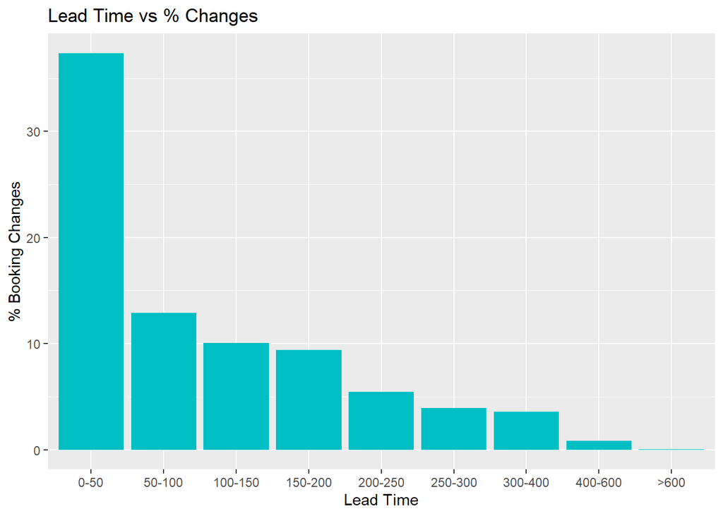

```r
total_changes<-sum(hotels$booking_changes)

  hotels %>%
    filter(is_canceled == 0) %>%
    mutate(
      lead_time_bucket = case_when(
        lead_time >= 0 & lead_time <= 50 ~ "0-50",
        lead_time > 50 & lead_time <= 100 ~ "50-100",
        lead_time > 100 & lead_time <= 150 ~ "100-150",
        lead_time > 150 & lead_time <= 200 ~ "150-200",
        lead_time > 200 & lead_time <= 250 ~ "200-250",
        lead_time > 250 & lead_time <= 300 ~ "250-300",
        lead_time > 200 & lead_time <= 400 ~ "300-400",
        lead_time > 400 & lead_time <= 600 ~ "400-600",
        lead_time > 600 ~ ">600"
      ),
      lead_time_bucket = fct_relevel(lead_time_bucket,
                                     "0-50","50-100","100-150","150-200","200-250","250-300","300-400", "400-600", ">600")
    )  %>% group_by(lead_time_bucket) %>%
    summarise(changes_percent = sum(booking_changes) / total_changes) %>%
    ggplot(aes(x = lead_time_bucket, y = changes_percent * 100)) +
    geom_bar(stat = "identity", fill = "#00BFC4") +
    xlab("Lead Time") +
    ylab("% Booking Changes") +
    ggtitle("Lead Time vs % Changes")
```

##### Hypothesis 2

**There is a significant relation between the room types and the adr**

To test the validity of our hypothesis we will use the following plot:

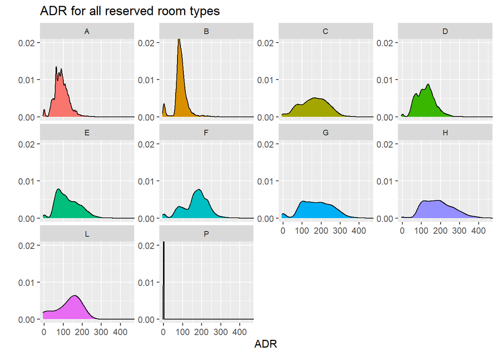

```r
library(hrbrthemes)
ggplot(data=hotels, aes(x=adr, group=reserved_room_type, fill=reserved_room_type)) +
    geom_density() +
  coord_cartesian(xlim = c(0,450),ylim = c(0,0.02)) +
  scale_y_continuous(breaks=seq(0,0.020,0.01)) +
  facet_wrap(~reserved_room_type,scale="free_y") +
  ggtitle("ADR for all reserved room types") +
  theme(legend.position="none",
        panel.spacing = unit(0.25, "lines"),
      strip.text.x = element_text(size = 8)) +
  xlab("ADR") +
  ylab("")
```

The plot above helps understand the distribution of ADR for each room. A peak to the right would indicate a higher ADR on average and a flatter spread would indicate that the ADR is spread out. from this particular plot we can infer that rooms types - A, B, E and, P have on average lower ADR than the other rooms that seem to have a much flatter and wider distribution. Interestingly, room type P has almost a bar which would indicate 0 to low ADR.

##### Hypothesis 3

**There is a relation between the distribution channel and ability of the hotel to provide the requested room**

The distribution channel can affect the ability of a hotel to provide the same room to a customer. To test the validity of our hypothesis we will use the following plot:

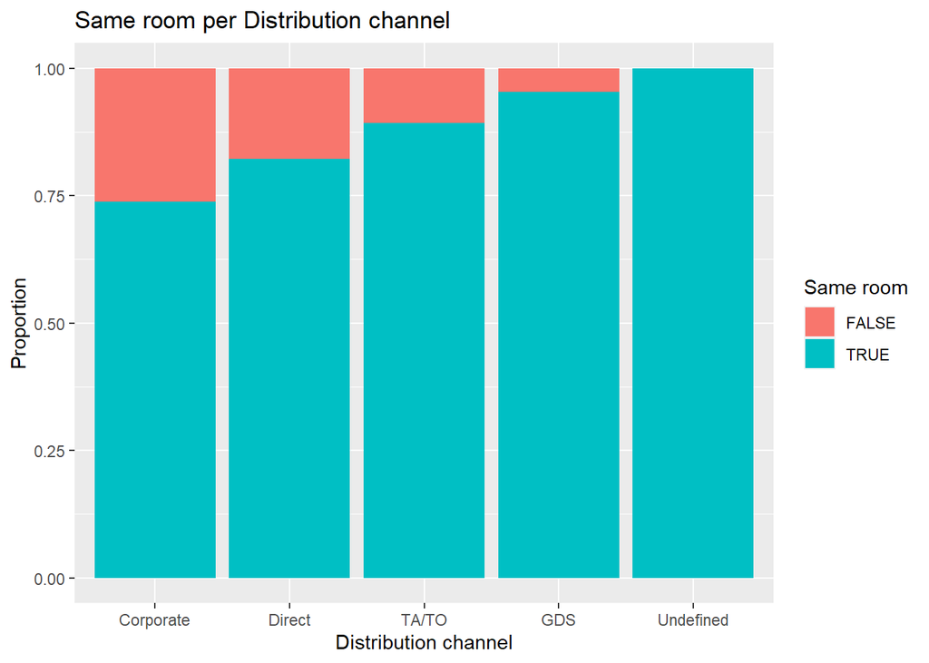

```r
hotels %>%
  mutate(distribution_channel = fct_relevel(distribution_channel,
                                            "Corporate","Direct","TA/TO","GDS","Undefined"))  %>%
  ggplot(aes(distribution_channel, fill = factor(same_room))) +
  geom_bar(position = "fill") +
  labs(fill = "Same room") +
  xlab("Distribution channel") +
  ylab("Proportion") +
  ggtitle("Same room per Distribution channel")
```

The plot above does show a small trend i.e. GDS > TA/TO > Direct > Corporate in the ability to provide the same room. To further investigate this relationship we will see if any one hotel type is causing this trend.

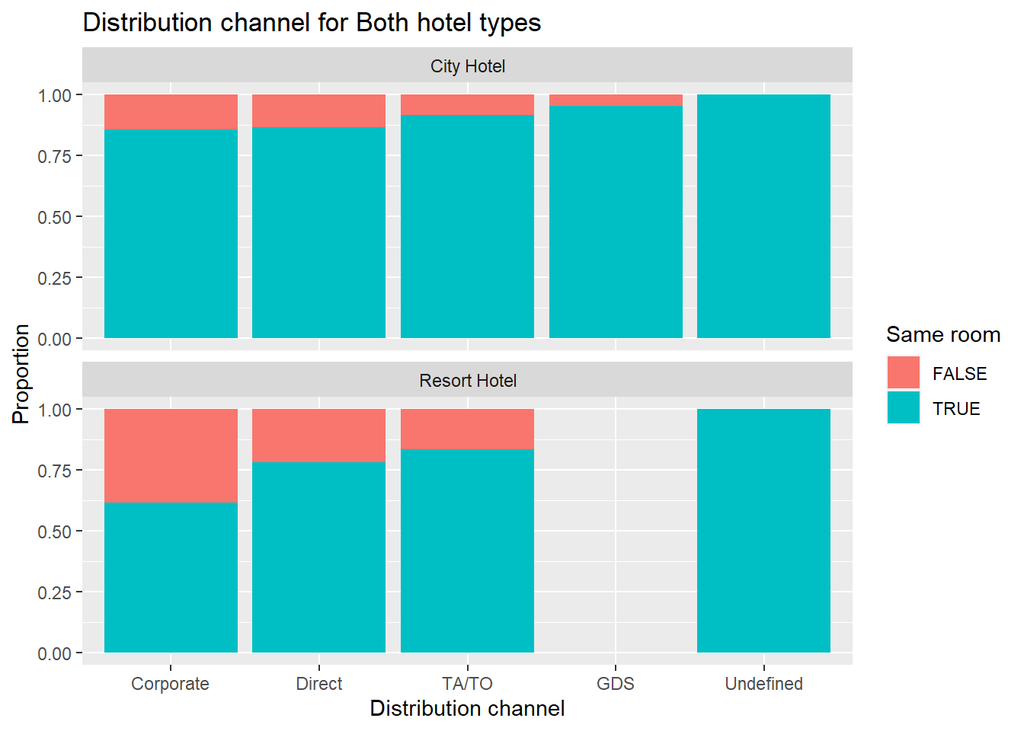

```r
hotels %>%
  mutate(distribution_channel = fct_relevel(distribution_channel,
                                            "Corporate","Direct","TA/TO","GDS","Undefined"))  %>%
  ggplot(aes(distribution_channel, fill = factor(same_room))) +
  geom_bar(position = "fill") +
  labs(fill = "Same room") +
  xlab("Distribution channel") +
  ylab("Proportion") +
  ggtitle("Distribution channel for Both hotel types") +
  facet_wrap(~hotel, nrow = 2)
```

The plot above shows that trend is independent of the hotel type as the same can be observed here.

##### Hypothesis 4

**Hotels in the city have greater traffic and are more susceptible to overbooking**

The ability of a hotel to provide the reserved room to the customer is essential in customer satisfaction. However, there are times when a hotel is unable to provide the same. Here we want to visualize the relation between overbooking and the location or type of the hotel and the number of bookings. To test the validity of our hypothesis we will use the following plot:

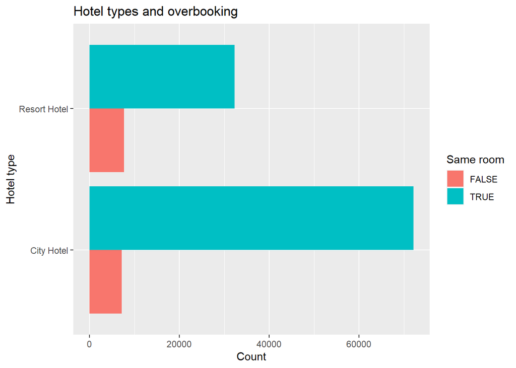

```r
ggplot(data = hotels, aes(hotel, fill = factor(same_room))) +
  geom_bar(position = "dodge") +
  labs(fill = "Same room") +
  coord_flip() +
  xlab("Hotel type") +
  ylab("Count")+
  ggtitle("Hotel types and overbooking")
```

Here we can see that `City Hotels` do in fact have greater foot traffic but contrary to our initial hypothesis we see that `Resort Hotels`, despite having less than half the number of bookings have the same if not more changes to the room type which can be associated to overbooking. Thus, the location and the type of the hotel do play a role in the ability of a hotel in providing the same room to a customer.

##### Hypothesis 5

**There is a significant relation between the market segment and the assigned room types**

There may be a relation between market segment and the reserved room types, the reason for this relation may be intrinsic or extrinsic to the room type. To test the validity of our hypothesis we will use the following plot:

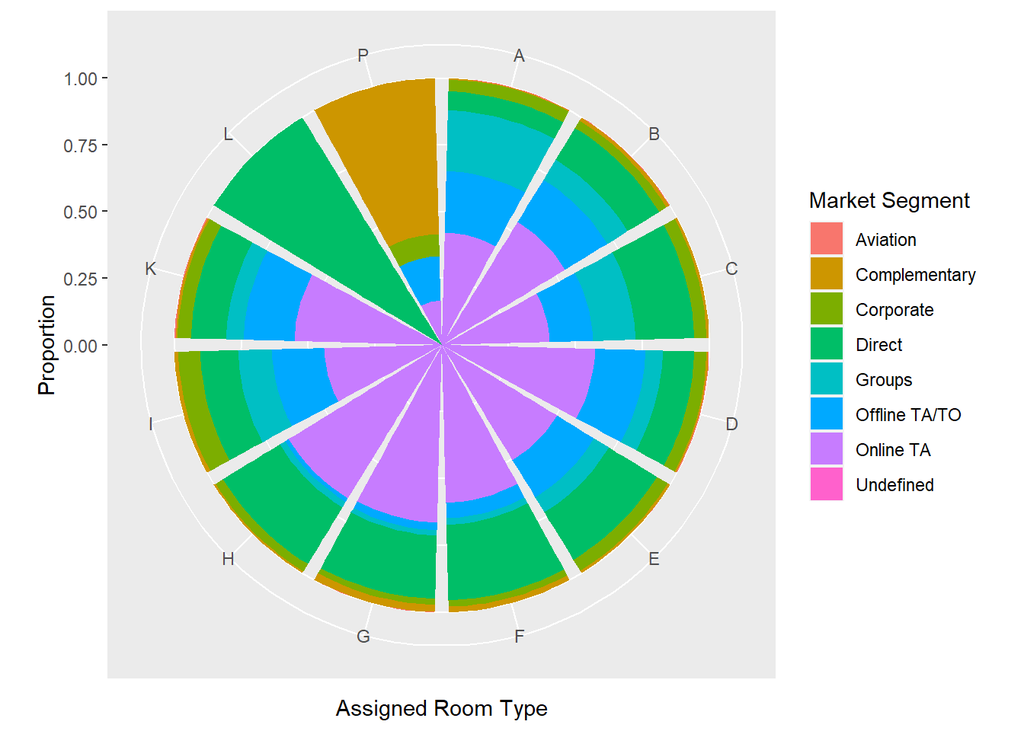

```r
ggplot(data = hotels, aes(assigned_room_type, fill = factor(market_segment))) +
  geom_bar(position = "fill") +
  coord_polar() +
  xlab("Assigned Room Type") +
  ylab("Proportion")+
  labs(fill = "Market Segment")
```

The plot above shows that only room types L and P are dominated by a single market segment and there is no relation for all other rooms to any single market segment.

##### Hypothesis 6

**There is a significant relation between the distribution channel and the reserved room types**

There may be a relation between distribution channel and the reserved room types, the reason for this relation may be intrinsic or extrinsic to the room type. To test the validity of our hypothesis we will use the following plot:

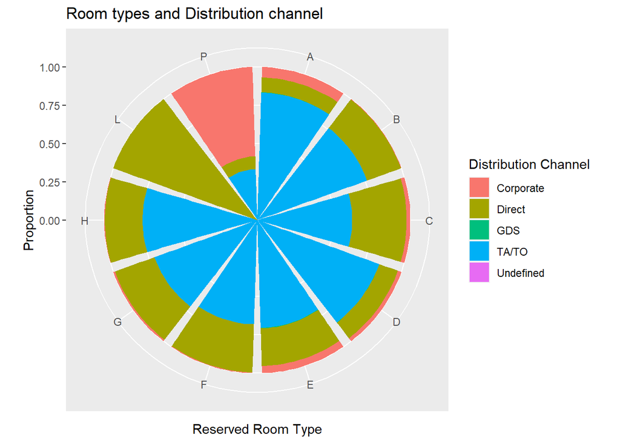

```r
ggplot(data = hotels, aes(reserved_room_type, fill = factor(distribution_channel))) +
  geom_bar(position = "fill") +
  coord_polar() +
  xlab("Reserved Room Type") +
  ylab("Proportion")+
  labs(fill = "Distribution Channel")+
  ggtitle("Room types and Distribution channel")
```

Rooms A, D, L and P are dominated by one distribution channel. Room L and P are for Direct and Corporate customers predominantly. This is in line with the plot above as room P was mostly complementary. In line with the above hypothesis we can conclude that there is no significant relation for all other rooms to any single market segment.

##### Hypothesis 7

**Certain room types can have a larger lead time**

To test the validity of our hypothesis we will use the following plot:

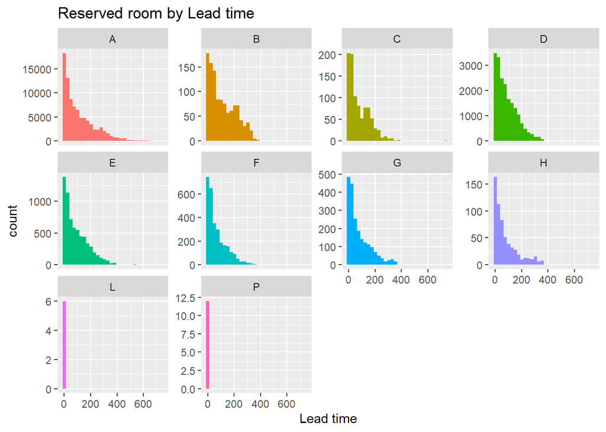

```r
ggplot(hotels, aes(lead_time,fill=reserved_room_type)) +
  geom_histogram() +
    labs(title="Reserved room by Lead time",
         x="Lead time")  +
  facet_wrap(~reserved_room_type, scale="free_y") +
  theme(legend.position="none")
```

##### Hypothesis 8

**People who do not pay deposit while booking tend to cancel the booking**

To test the above hypothesis we look at the trend of cancellations across deposit type and check the trend.

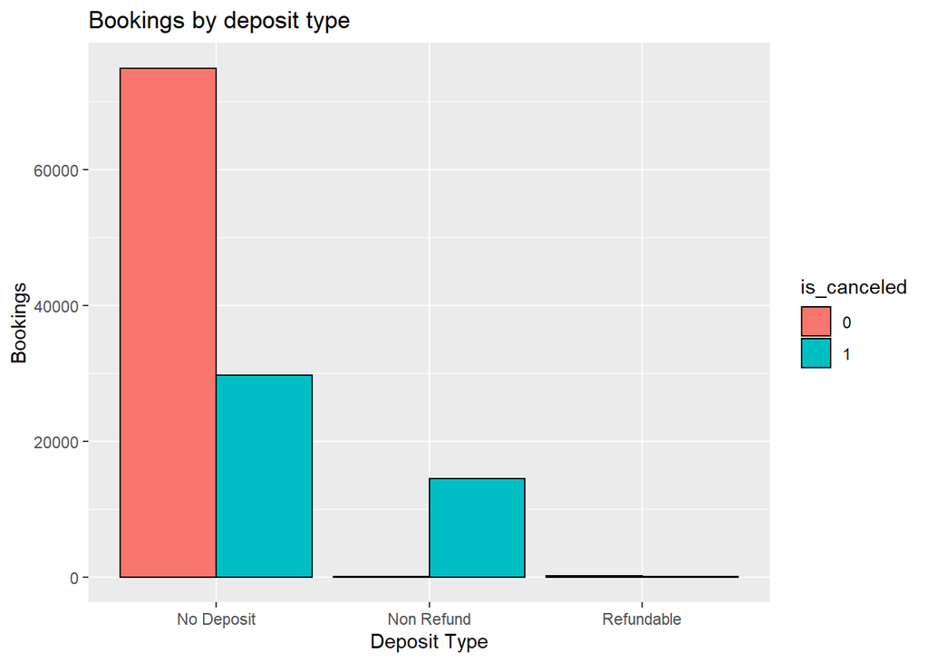

```r
hotels$is_canceled <- as.character(hotels$is_canceled)

deposit_canc <- ggplot(data=hotels, aes(x=factor(deposit_type), fill=is_canceled)) +
geom_bar(col = "black",stat="count", position=position_dodge()) +
  labs(title = "Bookings by deposit type", x = "Deposit Type", y = "Bookings")

deposit_canc
```

This shows us the most number of booking which get cancelled are where people have made no deposit for the booking. But this also gives us another interesting finding that the cancellation rate across booking with non refund is higher as compared to not cancelled bookings.

This helps us deduce that, the rate of overall cancelled bookings (bookings cancelled/booking cancelled+not cancelled) is much higher in case of Non-refund deposit type as compared to the bookings where deposit is not paid.

##### Hypothesis 9

**Groups with children tend to pay deposits while booking**

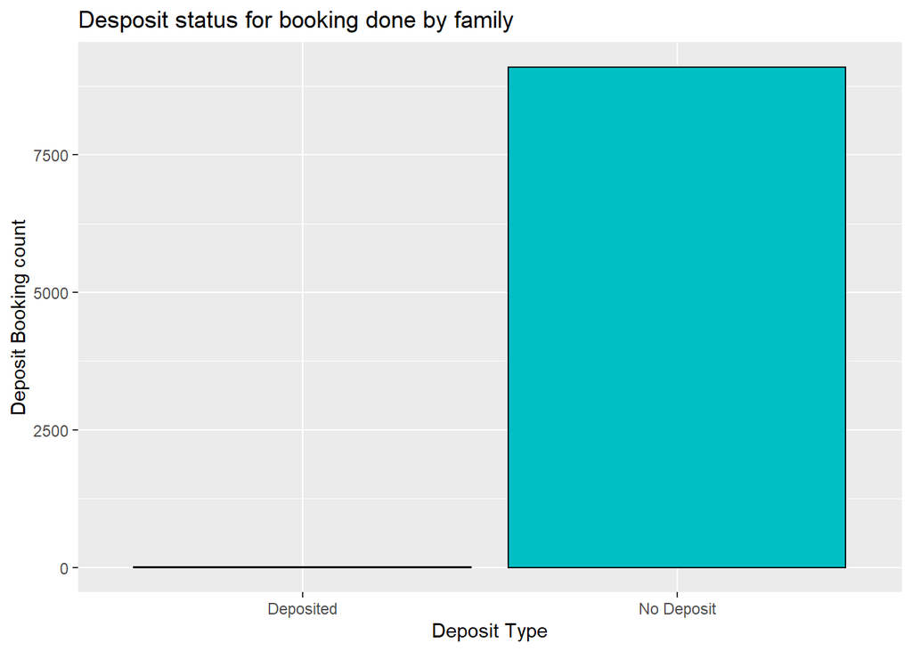

```r
temp_t  <- hotels %>%
        filter(is_family == TRUE) %>%
        select(is_family,is_deposit)

ggplot(temp_t,aes(x=is_deposit))+
  geom_bar(col="black", fill="#00BFC4")+
  ggtitle("Desposit status for booking done by family") +
            xlab("Deposit Type") +
            ylab("Deposit Booking count")
```

As per the plot, bookings made by the group members largely did not go for deposit.

##### Hypothesis 10

**Majority of the people tend to not pay deposits while booking**

This is a simple but significant insight, usually in hotel industry it is observed that the count for deposits while bookings are way less compared to no deposits.Let’s see the following plot to confirm this.

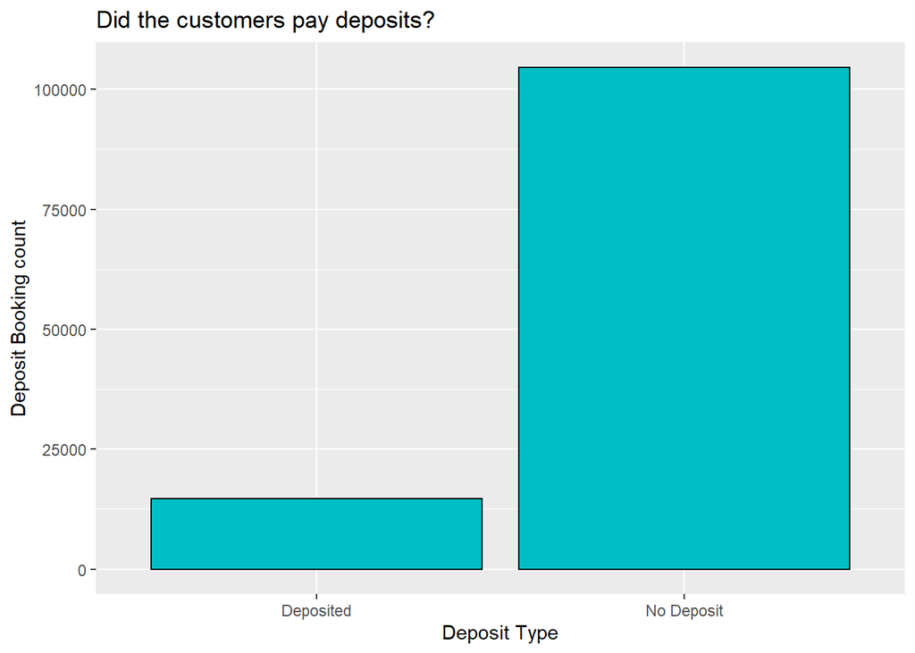

```r
ggplot(hotels,aes(is_deposit))+
  geom_bar(col="black", fill="#00BFC4")+
  ggtitle("Did the customers pay deposits?") +
            xlab("Deposit Type") +
            ylab("Deposit Booking count")
```

So,the plot confirms that usually customers do not pay deposits while booking.

### 4.5 Market Channel Features

#### 4.5.1 Hypothesis Proposed

The market channel metrics conveys the booking channel that was used by the customers for making the reservation. Our market channel metrics contain - Agent, Company, Distribution Channel and Market Segment. Based on our initial exploration we put forward the following hypothesis to gauge the impact of the booking channel on customer bookings:

- The bookings made through travel agencies tend to not get cancelled
- People with more family members tend to make bookings with travel agencies

On a overall level we see that customers prefer to make reservations through *online travel agencies* as we can see in the below plots for both `city Hotel` and `Resort Hotel`.

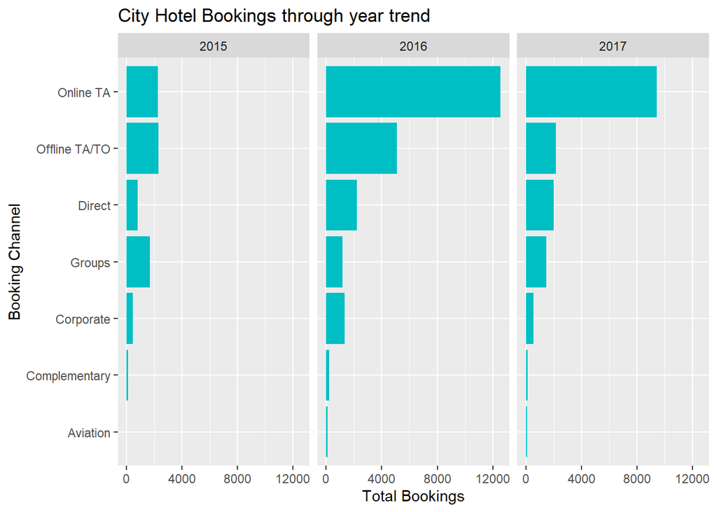

```r
hotel_mkseg <- hotels %>% select(hotel, arrival_date_year, market_segment, is_canceled) %>% filter(is_canceled == 0, ) %>%
              group_by(hotel, arrival_date_year, market_segment) %>% summarise(bookings = n())

ggplot(data = hotel_mkseg[hotel_mkseg$hotel == "City Hotel",], aes(x = reorder(market_segment, bookings), y = bookings)) +
  geom_bar(stat = "identity", fill = "#00BFC4") +
  coord_flip() +
  scale_y_continuous(name="Total Bookings") +
  scale_x_discrete(name="Booking Channel") +
  ggtitle("City Hotel Bookings through year trend") +
  facet_wrap(~arrival_date_year)
```

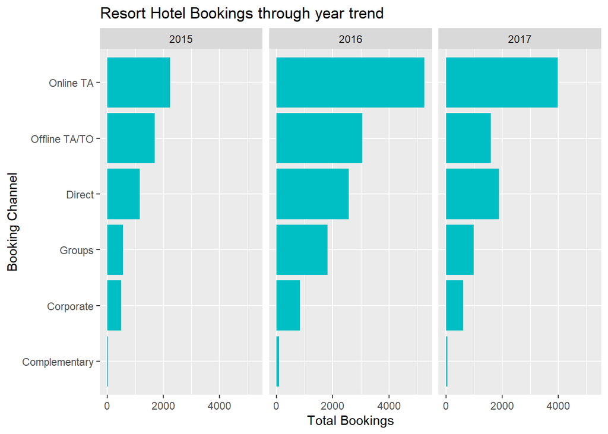

```r
ggplot(data = hotel_mkseg[hotel_mkseg$hotel == "Resort Hotel",], aes(x = reorder(market_segment, bookings), y = bookings)) +
  geom_bar(stat = "identity", fill = "#00BFC4") +
  coord_flip() +
  scale_y_continuous(name="Total Bookings") +
  scale_x_discrete(name="Booking Channel") +
  ggtitle("Resort Hotel Bookings through year trend") +
  facet_wrap(~arrival_date_year)
```

#### 4.5.2 Analysis and Trends to Answer Key Questions

Based on the above data exploration we now check our data for trends to validate our proposed hypothesis to devise strategies to hotel bookings.

##### Hypothesis 1

**People with more family members tend to make bookings with travel agencies**

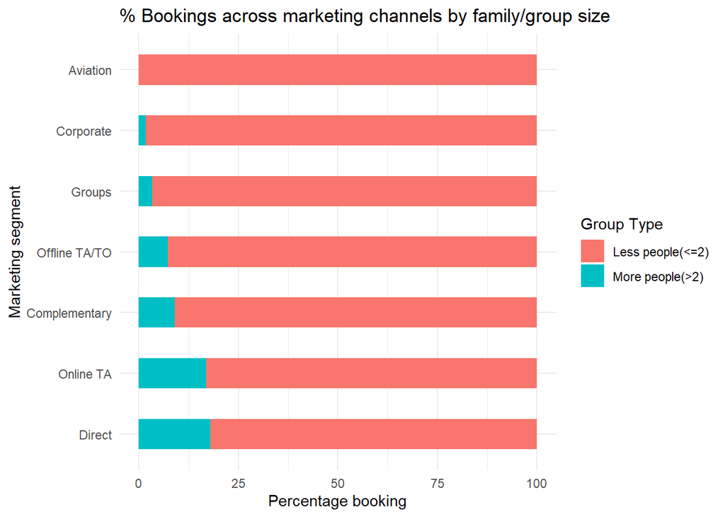

```r
hotels$members = hotels$adults + hotels$children + hotels$babies
hotels_not_cancelled <- hotels %>% filter(is_canceled==0)
hotels_not_cancelled <- hotels_not_cancelled %>%
  mutate(flag = if_else(members > 2, "More people(>2)","Less people(<=2)"))

hotels_not_cancelled$flag <- as.character(hotels_not_cancelled$flag)

hotel_sub_mktg <- hotels_not_cancelled %>%
  mutate(market_segment = fct_relevel(market_segment,"Direct","Online TA","Complementary","Offline TA/TO","Groups","Corporate","Aviation")) %>%
  group_by(market_segment, flag) %>%
  summarise(count = n()) %>%
  mutate(perc = count/sum(count))

ggplot(hotel_sub_mktg, aes(x = factor(market_segment), y = perc*100, fill = factor(flag))) +
  geom_bar(stat="identity", width = 0.5) +
  labs(x = "Marketing segment", y = "Percentage booking", fill = "Group Type") +
ggtitle("% Bookings across marketing channels by family/group size")  +
  theme_minimal() +
  coord_flip()
```

##### Hypothesis 2

**The bookings made through travel agencies tend to not get cancelled**

In order to test the validity of the second hypothesis proposed, we will filter the bookings made through travel agencies from the market_segment and plot these booking against the cancellation flag is_canceled. This plot will help us accept or reject the hypothesis.

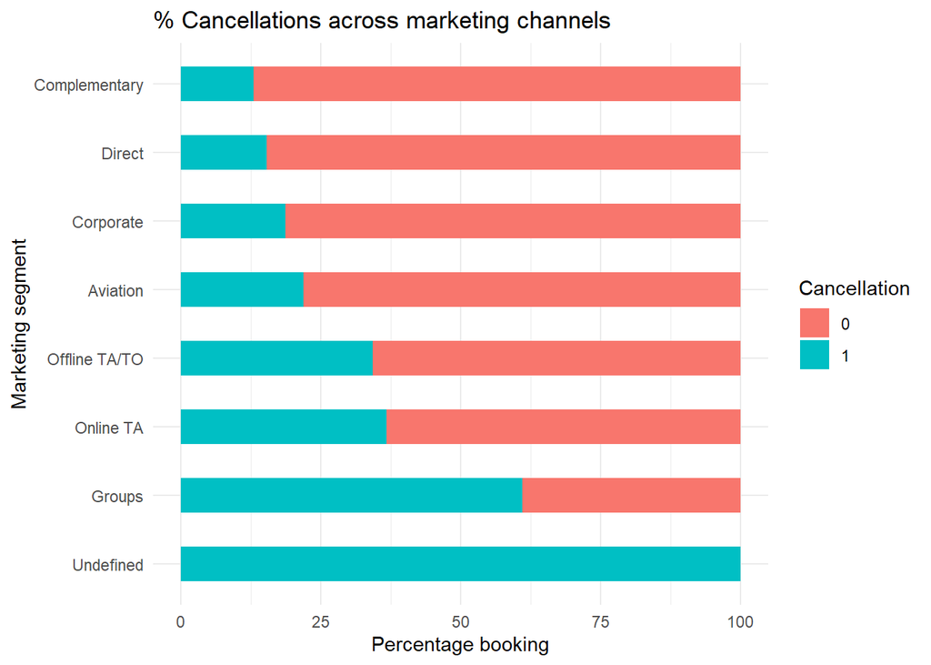

```r
hotels$is_canceled <- as.character(hotels$is_canceled)

hotels_sub <- hotels %>%
   mutate(market_segment = fct_relevel(market_segment,"Undefined","Groups","Online TA","Offline TA/TO","Aviation","Corporate",
"Direct","Complementary"))%>%
  group_by(market_segment, is_canceled) %>%
  summarise(count = n()) %>%
  mutate(perc = count/sum(count))

ggplot(hotels_sub, aes(x = factor(market_segment), y = perc*100, fill = factor(is_canceled))) +
  geom_bar(stat="identity", width = 0.5) +
  labs(x = "Marketing segment", y = "Percentage booking", fill = "Cancellation") +
ggtitle("% Cancellations across marketing channels ")  +
  theme_minimal() +
  coord_flip()
```

## 5. Insights and Recommendations

Below are a few recommendations based on our analysis:

1. **Early Bird Offers**: We observe that a lot of cancellations occur in the last few lead time buckets. To reduce these we can introduce early bird discounts as pricing is most likely the reason that these bookings get dropped
2. **Double Book Anticipating Cancellations**: When the party size is greater than 12 we notice that the cancellation rate is 100%, so it maybe valuable to double book the rooms allocated in such instances so as to not lose out on bookings
3. **Testing Out New Services**: Special service requests are high in the summer months, this might be the best time to test out planned service launches as customers tend to opt for them during these months
4. **Offering Bump-ups on Meal Services**: To improve traction for the less preferred meal services, discounts can be offered on service bump-ups, i.e. SC/Undefined to BB, BB to HB and HB to FB
5. **Incentive to Improve Bookings with Deposit Count**: Deposit based bookings can be promoted by reducing prices on them, this is often employed by travel booking websites

## 6. Conclusion

The objective of the exploration was to understand the key drivers behind Resort and City hotel bookings in Portugal. From the detailed analysis we were able to identify few key drivers like - lead time, group size, service types, etc. Based on these influential factors, strategic and marketing recommendations were devised. These factor identification can be further leveraged to understand sales fluctuations, booking prediction and campaign design for hotels from this regions. Few of the broader insights can be leveraged across the hotel industry.